# Topic Modeling - LDA

class notes

# Introduction

In text mining, we often have collections of documents, such as blog posts or news articles, that we would like to divide into natural groups so that we can understand them separately. Topic modeling is is a statistical technique used in natural language processing (NLP) to discover abstract topics within a collection of documents. By doing so, it enables the revelation of underlying subjects or motifs discussed across the corpus without necessitating prior knowledge of the topics. It is an unsupervised method of documents, similar to PCA on numeric data. You could think of topic modeling as a set of “amplified reading” techniques.

As David Blei puts it:

> topic modeling algorithms do not require any prior annotations or labeling of the documents. The topics emerge from the analysis of the original texts. Topic modeling enables us to organize and summarize (…) archives at a scale that would be impossible by human annotation (Blei 2012)

There are several methods for implementing a topic model. However, Latent Dirichlet Allocation (LDA) stands out as particularly favored. LDA conceptualizes each document as a mixture of various topics, and each topic as a mixture of words. This permits documents to exhibit overlaps in terms of content.

# Latent Dirichlet Allocation (LDA)

Latent Dirichlet Allocation (LDA) is one of the most popular techniques for topic modeling. It was introduced by David Blei, Andrew Ng, and Michael Jordan in 2003 (Blei, Ng, and Jordan 2003). LDA assumes that each document in a corpus is a mixture of various topics and that each word in the document has a specific probability to belong to any topic.

Therefore, a topic is a probability distribution in the word space and a document is a probability distribution in the topic space.

An intuition on LDA can be seen in the following figure:

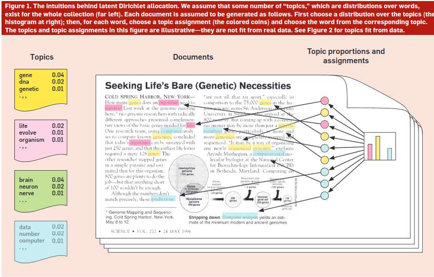

**Source:** (Blei 2012)

¿How does LDA algorithm works?

LDA starts by randomly assigning each word in each document to one of the K topics, where K is a pre-defined number of topics chosen by the user.

LDA assumes that these topics are pre-existent: they are defined before any data has been generated. So, the number of topics (generally, named $k$) is an hyperparameter.

For every document within the corpus, we initiate the generation of its words through a two-step procedure:

1. Initially, we randomly select a distribution over topics.
2. Subsequently, for each word present in the document:
   1. We randomly select a topic from the distribution over topics determined in the first step.
   2. Then, we randomly select a word from the corresponding distribution over the vocabulary associated with the chosen topic.

The workflow of LDA can be summarised in the next figure:

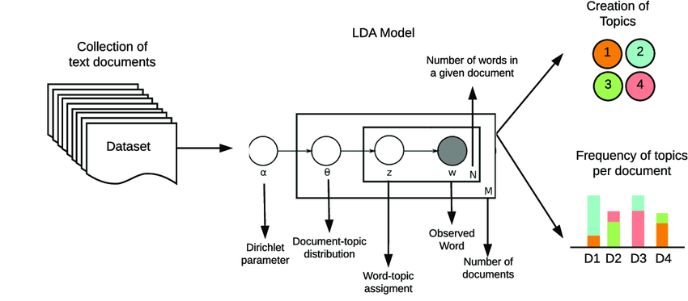

# Outputs and interpretation

There are two main outputs in LDA:

**- Topic-Term Matrix:** This matrix represents the distribution of words for each topic. Each row corresponds to a topic, and each column corresponds to a word in the vocabulary. The values in the matrix represent the probability of each word occurring in each topic.

**- Document-Topic Matrix:** This matrix represents the distribution of topics for each document. Each row corresponds to a document, and each column corresponds to a topic. The values in the matrix represent the probability of each topic occurring in each document.

Based on these matrices it is possible to construct some summaries in order to gain a more accurate of the underlying themes present in the corpus, understand the topics discussed in individual documents, and explore relationships between topics and documents.

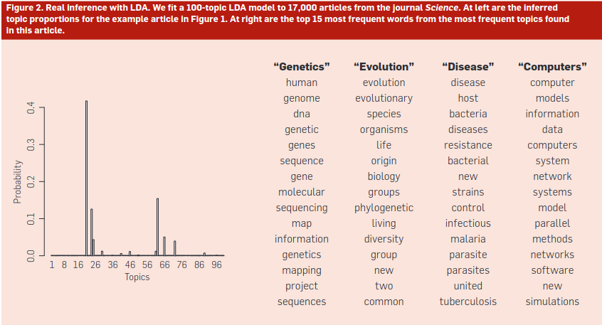

**Source:** (Blei 2012)

Thus, words such as “human,” “genome,” “DNA,” suggest a topic linked to **genetics**. Likewise, “evolution,” “species,” “life,” seem to speak of a topic about **evolution**. We can repeate this exercise with each one of the topics estimated in a LDA model.

# How many topics?

As you can imagine, select the $k$ value is not simple. There are various metrics that allow quantifying the fit (i.e., how “good” it is) of the number of topics defined in quantitative terms (log-likelihood, perplexity, etc.).

Here we briefly define one of the possible metrics to use to select the optimum number of topics.

## Perplexity

Perplexity is a statistical measure used to assess the effectiveness of a probabilistic model in predicting a sample or a sequence of data. It is commonly employed in natural language processing tasks, particularly in the evaluation of language models such as Latent Dirichlet Allocation (LDA) for topic modeling.

At its core, perplexity quantifies how well a probability distribution or model captures the complexity of observed data. The term “perplexity” originates from information theory and represents the level of surprise or uncertainty associated with predicting each subsequent symbol in a sequence.

In the context of language modeling, perplexity evaluates how well a model predicts a sequence of words or tokens. A lower perplexity indicates that the model assigns higher probabilities to the observed data, implying that the model is more confident and less uncertain in its predictions.

Mathematically, perplexity is calculated as the inverse probability of the test set, normalized by the number of words:

$$Perplexity = \exp\left\{-\frac{\sum_{i=1}^{N} \log p(w_i)}{N}\right\}$$

- $N$ is the total number of words or tokens in the test set.
- $p(w_{i})$ is the probability assigned by the model to the $i^{ith}$ word or token in the test set

Essentially, perplexity measures the average branching factor of a decision tree based on the model’s predictions. A lower perplexity indicates that the model assigns higher probabilities to the observed data, implying better predictive performance and lower uncertainty.

It would be possible, then,

1. to generate a holdout set (using train-test split, cross-validation, etc.),
2. train several models for different values of $k$
3. calculate on the hold-out set the perplexity
4. select the $k$ which minimizes perplexity

## “Qualitative” determination of $k$

As you can imagine, the use of these metrics leads to models that achieve good statistical performance but may not necessarily generate interpretable topics.

A larger number of topics tends to yield better metrics and allows for a high resolution of the latent structure of the corpus. However, it has been observed that increasing the number of topics tends to decrease the quality of the topics (in terms of interpretability) (Mimno et al. 2011) (Chang et al. 2009). Thus, similar to many other problems, model complexity and interpretability tend to move in opposite directions.

Therefore, it is often possible to use other approaches to select the number of topics. In general, we could think of two main ways to do this:

- we could define a relatively small number of topics and try to make them all “interpretable”
- we could estimate a large number of topics and only consider those that are relevant to our analysis questions; this is the method that (Diego Kozlowski and Altszyler 2023) followed in the paper we will discuss in the next section.

Which approach is the most suitable? This will depend on the research questions and the type of corpus being worked with. If it is a relatively homogeneous corpus and the interest is to have an initial overview of its content, perhaps the first approach may be more fruitful (“few but good”). If, on the other hand, it is a potentially very diverse corpus and we are looking to detect some specific topics, then the second approach might work better.

Up to this point, we have thought of LDA (or any topic modeling technique) as the endpoint of the analysis. Once we train a certain $k$ that is satisfactory, we move on to model validation and interpretation. However, we can also think of it as a starting point. For example, we can use topic modeling to have an initial descriptive overview of a given corpus and to “guide” a deep reading of some documents in the corpus. Suppose we have a very large corpus of textual documents. We could not read the entire corpus, and on the other hand, we would like to have some idea of how to choose documents to read. We train an LDA model and obtain a topic related to labor disputes and another one about the political situation. We could sample documents with a high prevalence in those topics of interest to advance “intelligently” in qualitative reading of the corpus.

We can also use it as part of the preprocessing of a corpus and the feature construction process. It is common for a corpus to contain documents or parts of documents in languages other than the majority language of the corpus. If this were to happen, it is highly likely that one or several topics would concentrate terms in that language. Since we can also obtain the topic distribution per document, it would be very easy to clean the texts that do not correspond to the majority language: we simply filter out those documents with a high prevalence in the topic that groups terms in another language.

But we can also think of the topic-document matrix as features to be used. Instead of having a TDM of around 4000 columns or more, we can use the document-topic matrix as a more concise and less sparse representation of each document and use it as features for a text classification model.

# Discussion

What kind of applications can be made using these techniques? How can they be used from a critical perspective that aligns with the interests of marginalized communities or identities?

Here we will discuss two critical applications of LDA. The first (Diego Kozlowski and Altszyler 2023) aims to advance the identification of gender stereotypes. For this, they work with a corpus of about 24,000 articles from magazines oriented towards women and men and seek to detect the main topics of each magazine and analyze their distribution over time. The results showed that topics such as Family, Business, and Women as sexual objects present a prevalence and bias that fades over time. In contrast, in topics like “Fashion” or “Science”, the differences between magazines for men and women remain.

A second study (Kozlowski et al. 2022) allowed correlating topics in scientific literature with certain identities linked to race and gender. They worked with a large-scale bibliometric analysis (about 5,431,451 articles indexed in the Web of Science database and 1,609,107 distinct US first authors). They used LDA on the title, abstract, and keywords of each article to infer the topics of the corpus and the topic distribution per article. Strong correlations are observed both in academic impact and in topics with the identities constructed in the paper. For example, women are generally underrepresented in hard sciences and mathematics and overrepresented in the field of health.

## Some limitations on LDA

However, beyond these limitations, there are a series of assumptions in LDA that can be problematic for many applications in social sciences. Some of them are based on the use of the Bag of Words model. We will return to them at the end of this section.

Here we would like to emphasize some specific limitations of LDA:

1. Topics are independent of each other.
2. The distribution of words within a topic (the content of a topic) is constant. Document 1 uses the same words to compose topic 1 as document 2, 3, etc.
3. The estimation of topics is done exclusively based on the text of each document in the corpus, without incorporating any other type of information.

Let’s consider, for example, a study over a long period of time, like the work by (Blei 2012) that we mentioned, containing scientific articles spanning over 100 years. There is a possibility that the way of “talking” about “genetics” may have changed between the late 19th century and the present, and that different terms are used.

## Structural Topic Modeling (STM)

STM (Structural Topic Modeling) is a topic modeling technique that aims to address some of the limitations mentioned above. The main feature is that it allows the introduction of covariates, meaning it allows topics to vary based on one or more metadata variables of the text (publication date, author’s gender, nationality, publication type, etc.). Any information about the documents can be used in STM.

Thus, we first need to define two “dimensions”: topic content and topic prevalence. The former refers to the composition of words that form each topic. The latter refers to the composition of topics that constitute each document. STM will allow the introduction of covariates that affect both dimensions.

In LDA, topic prevalence comes from a [Dirichlet distribution](https://en.wikipedia.org/wiki/Dirichlet_distribution) with parameters set in advance. In STM, topic prevalence and content incorporate information from the metadata of each document, meaning they vary with each document. In general, the matrix with metadata used to generate the topic prevalence matrix is often denoted as $X$, while the matrix with metadata used to generate the topic content matrix is denoted as $Y$. Logically, different metadata can be used in each case ($X \neq Y$), or the same information can be used in both cases ($X = Y$). We can also use metadata only in topic content or only in topic prevalence.

**Topic prevalence**

**Topic content**

## Limitations of Bag of Words

As mentioned above, these topic modeling techniques are based on the Bag of Words model. This way of vectorizing text has some advantages:

- it is simple: it is easy to explain that we are simply counting the frequency of occurrence of each word in the vocabulary in each document
- it is easy to implement

However, it has some limitations that need to be mentioned:

- it is insensitive to the order of words
- it does not take into account grammatical structure
- it fails to fully capture semantic relationships between words: the BoW model only captures the frequency of occurrence of a word in each document, as it does not incorporate information about the context (around which other words co-occur), the semantic information it captures is limited
- it has high dimensionality: it is common for the vocabulary size of an average corpus to be high, above 10,000 words; this means that our TFM will have about 10,000 columns
- it has high sparsity: in turn, since a document only uses a limited subset of terms from the vocabulary, it is expected that the TFM will contain many empty elements (zeros); this poses a problem when calculating similarity or correlation metrics between documents or words.

For example, consider the following sentences:

- “On the table there is a vase with daisies and jasmines”
- “The glass full of flowers is resting on a counter”

Both sentences convey the same semantic meaning, but they do not have any words in common. In our TFM, they would occupy completely different vectors.

Working with word embeddings allows us to address these limitations, as we will see in the next class.

# BERTopic

While we will not be using this technique in the course (since there is only one implementation in Python), it is important to mention some characteristics of BerTopic. In a way, this technique combines many of the most modern NLP techniques (at least until the arrival of LLMs) into a classic problem: topic detection.

You can find the documentation and a detailed review of the model [here]((https://maartengr.github.io/BERTopic/index.html). In this course, we would like to mention some of its most relevant features.

BERTopic is a state-of-the-art topic modeling technique that harnesses the power of pre-trained BERT (Bidirectional Encoder Representations from Transformers) embeddings to identify coherent topics within a corpus of text data. Let’s delve into a detailed review of its inner workings:

[figure not shown]

**Source:** [BERTopic site](https://maartengr.github.io/BERTopic/algorithm/algorithm.html#visual-overview)

**1. Pre-trained BERT Embeddings:** BERTopic starts by leveraging pre-trained BERT models, which are trained on vast amounts of textual data using a powerful Transformer architecture. These models encode each word or token in the document into dense vector representations that capture rich semantic information.

**2. Document Embeddings** Each document in the corpus is fed into the pre-trained BERT model, and the final hidden state corresponding to the [CLS] token is extracted. This [CLS] token represents an aggregated representation of the entire document, encapsulating its semantic meaning.

**3. Dimensionality Reduction:** To reduce the dimensionality of the dense document embeddings while preserving semantic relationships, BERTopic applies dimensionality reduction techniques such as UMAP (Uniform Manifold Approximation and Projection) or t-SNE (t-distributed Stochastic Neighbor Embedding).

**4. Hierarchical Clustering:** The reduced-dimensional embeddings are then clustered using hierarchical clustering algorithms such as HDBSCAN (Hierarchical Density-Based Spatial Clustering of Applications with Noise) or K-Means. Hierarchical clustering allows for the identification of coherent topic clusters based on the semantic similarity of documents.

**Topic Representation:** After clustering, each document is assigned to the most representative topic cluster. BERTopic also identifies representative keywords for each topic cluster by analyzing the most frequent words within the documents assigned to that cluster.

One last important aspect is its modular nature. Each of the stages mentioned above can be carried out by different models. For example, instead of using S-BERT for generating embeddings, Word2Vec or a similar technique could be employed. Similarly, the dimensionality reduction stage could be performed by PCA instead of UMAP. In fact, the use of LLMs is already being implemented.

## References

Blei, David M. 2012. “Probabilistic Topic Models.” *Commun. ACM* 55 (4): 77–84. https://doi.org/10.1145/2133806.2133826.

Blei, David M., Andrew Y. Ng, and Michael I. Jordan. 2003. “Latent Dirichlet Allocation.” *J. Mach. Learn. Res.* 3 (March): 993–1022. https://doi.org/10.5555/944919.944937.

Chang, Jonathan, Sean Gerrish, Chong Wang, Jordan Boyd-graber, and David Blei. 2009. “Reading Tea Leaves: How Humans Interpret Topic Models.” In *Advances in Neural Information Processing Systems*, edited by Y. Bengio, D. Schuurmans, J. Lafferty, C. Williams, and A. Culotta. Vol. 22. Curran Associates, Inc. https://proceedings.neurips.cc/paper_files/paper/2009/file/f92586a25bb3145facd64ab20fd554ff-Paper.pdf.

Diego Kozlowski, Carla M. Felcher, Gabriela Lozano, and Edgar Altszyler. 2023. “Large-Scale Computational Content Analysis on Magazines Targeting Men and Women: The Case of Argentina 2008-2018.” *Feminist Media Studies* 23 (5): 2235–53. https://doi.org/10.1080/14680777.2022.2047090.

Kozlowski, Diego, Vincent Larivière, Cassidy R. Sugimoto, and Thema Monroe-White. 2022. “Intersectional Inequalities in Science.” *Proceedings of the National Academy of Sciences* 119 (2): e2113067119. https://doi.org/10.1073/pnas.2113067119.

Mimno, David, Hanna Wallach, Edmund Talley, Miriam Leenders, and Andrew McCallum. 2011. “Optimizing Semantic Coherence in Topic Models.” In *Proceedings of the 2011 Conference on Empirical Methods in Natural Language Processing*, edited by Regina Barzilay and Mark Johnson, 262–72. Edinburgh, Scotland, UK.: Association for Computational Linguistics. https://aclanthology.org/D11-1024.